# (Prosper EDA)

## by (Gamal Eldin Samy)

## Introduction

Prosper is a peer-to-peer (P2P) lending platform. Investors on the site can invest as little as $25 in personal loans to other people. All personal loans issued on the site are unsecured personal loans with fixed interest rates. Prosper uses a ranking system on loans to rate loans on a scale of AA to F. AA have the lowest yields, and are the least likely to default. F loans have the highest yield, but are most likely to default. However, peer-to-peer lending is still a relatively unknown investment opportunity.

The Prosper dataset(last updated on 03/11/2014) contains four kinds of variable categories during 2006 to 2014:

- **Loan Status** : The status of the loan listed such as Cancelled, Chargedoff, Completed, Current, Defaulted, FinalPaymentInProgress, PastDue.
- **Borrower Data** : Basic properties about borrowers such as credit score, occupation, employment status, etc.
- **Loan Data** : Basic properties about the loan such as length of the loan(term), Borrower APR, etc.
- **Credit Risk Matrices** : Matrices measured the risk of loans, such as Credit grade, Prosper Score, bank card utilization, etc.
- **Prosper Customers with history**: How many loans they previously received, if they paid on time or not, etc.

### A list of important variables

**Loan-related**:

- LoanOriginalAmount
- LoanOriginationQuarter
- Term
- ListingCategory
- BorrowerRate
- BorrowerAPR

**Borrower-related**:

- BorrowerState
- Occupation
- EmploymentStatus
- EmploymentStatusDuration
- IsBorrowerHomeowner
- IncomeRange
- IncomeVerifiable
- StatedMonthlyIncome
- Recommendations

**LoanStatus**

**Risk-Metrics-related**:

- CreditGrade (pre Q3 2009)
- ProsperRating (num&alpha) (starting from Q3 2009)
- ProsperScore
- CreditScoreRangeLower
- CreditScoreRangeUpper
- InquiriesLast6Months
- DelinquenciesLast7Years
- PublicRecordsLast12Months
- RevolvingCreditBalance
- BankCardUtilization
- AvailableBankcardCredit
- TradesOpenedLast6Months
- DebtToIncomeRatio

**Customers-with-history-related**:

- TotalProsperLoans
- OnTimeProsperPayments
- ProsperPaymentsLessThanOneMonthLate
- ProsperPaymentsOneMonthPlusLate
- ProsperPrincipleOutstanding
- ScorexChangeAtTimeOfListing

**Investors**

### The Questions:

- What was the reason behind the company reconstruction in 2009?
- What affects the borrower’s APR or interest rate?

### General Properties of The Dataset

```python
print('The dataset consists of {} loan records and {} variables'.format(raw.shape[0], raw.shape[1]))
```

```
The dataset consists of 113937 loan records and 81 variables
```

```python
print('The number of variables has been reduced from {} to {}'.format(raw.shape[1], prosper.shape[1]))
```

```
The number of variables has been reduced from 81 to 38
```

According to the [sheet](https://docs.google.com/spreadsheets/d/1gDyi_L4UvIrLTEC6Wri5nbaMmkGmLQBk-Yx3z0XDEtI/edit#gid=0) giving a description of available variables, there are two versions of the company. The thing that made me pay a visit to a reviewing [website](https://www.lendacademy.com/prosper-review/) and I quote:

> When investors consider Prosper as an investment they need to remember that there have really been two iterations of the company. **Prosper 1.0 was from their beginning in 2006 to 2008** when underwriting standards were very lax (the minimum credit score was 520) and investor returns, on average, were negative. **Prosper 2.0 is from 2009 to the present day** when underwriting standards improved dramatically (minimum FICO score is now 640) and returns for investors have been much better.

Also to zoom in on the controlling factors of BorrowerAPR, it's worth noting the following:

> One unique part of the way Prosper ranks borrowers is that they use more than just a loan grade – there is also a Prosper Score ranging from 1-11. This is a score that they have developed internally based on the payment history of actual borrowers on their platform. *They use both the Prosper score and the borrowers credit information to determine the interest rate* and the estimated loss rate.

### Main Features for Analysis

- BorrowerAPR
- CreditGrade (pre Q3 2009)
- ProsperRating
- ProsperScore (starting from Q3 2009)
- Most of the data related to previous customers of Prosper
- Borrower-credit-related information
- Borrower background information

## 1. Getting to know the borrowers

### Borrower State Distribution

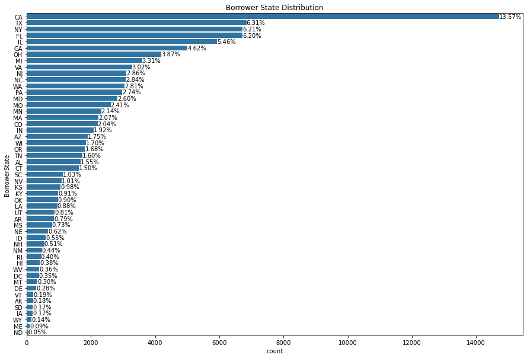

```python
cat_hbarplot(prosper_clean, 'BorrowerState', 'Borrower State Distribution')
```

Top 5 states with the biggest number of customers: California, Texas, New York, Florida, and Illinois

### Employment Status

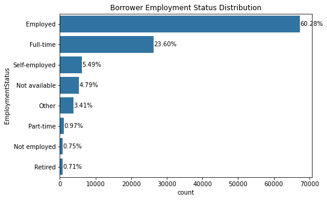

```python
cat_hbarplot(prosper_clean, 'EmploymentStatus', 'Borrower Employment Status Distribution', graph_height=5)
```

Obviously, the greatest proportion of borrowers are employed or working full-time jobs, but it's intriguing to find out why retired and not employed are guranteed loan in the first place. These two categories most probably have a very strong credit or some sort of a helthy investment to prove their worth of a loan we need more digging!

### Employment Status Duration

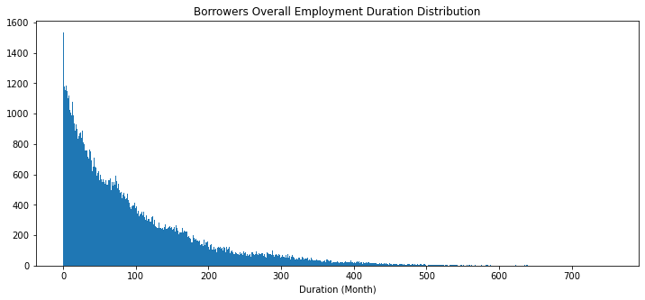

```python
# Employment Status Duration distribution
plt.figure(figsize=[12, 5]);
binsize = 1
bins = np.arange(prosper_clean['EmploymentStatusDuration'].min(), prosper_clean['EmploymentStatusDuration'].max()+binsize, binsize)
plt.hist(data=prosper_clean,
         x='EmploymentStatusDuration',
         bins=bins)
plt.xlabel('Duration (Month)')
plt.title('Borrowers Overall Employment Duration Distribution');
```

The distribution is heavily right-skewed. Many borrowers tend to apply to and receive a loan at the beginning of their tenure irrespective of their employment status.

### Income

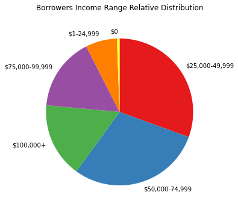

```python
sorted_counts = prosper_clean['IncomeRange'].value_counts()
plt.figure(figsize=[8, 5])
plt.pie(sorted_counts,
        labels=[i for i in sorted_counts.index],
        startangle=90,
        counterclock=False, colors=sb.color_palette("Set1"));
plt.axis('square');
plt.title('Borrowers Income Range Relative Distribution', loc='center', y=1.1);
```

Most of the borrowers fall in the middle-income ranges (25k - 75k)

### Stated Monthly Income

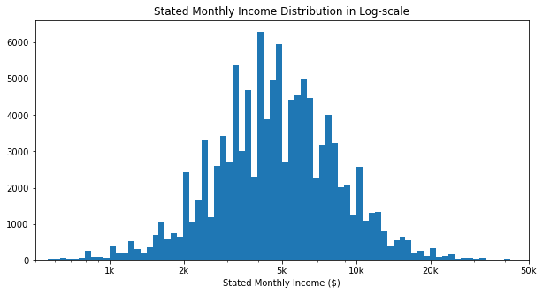

```python
def log_trans(x, inverse=False):
    if not inverse:
        return np.log10(x)
    else:
        return np.power(10, x)

#  transforming the bins to the log scale
log_binsize = 0.025
bins = 10 ** np.arange(log_trans(10), log_trans(prosper_clean['StatedMonthlyIncome'].max())+log_binsize, log_binsize)

plt.figure(figsize=[10, 5])
plt.hist(data=prosper_clean,
         x = 'StatedMonthlyIncome',
         bins = bins)
plt.xscale('log')

#  limiting the data to values between 500 and 50K where most of the data fall between
plt.xlim(5e2, 5e4)

#  using proper tick values and their right locations
plt.xticks([1e3, 2e3, 5e3, 1e4, 2e4, 5e4],
           ['1k', '2k','5k', '10k', '20k', '50k'])
plt.xlabel('Stated Monthly Income ($)')
plt.title('Stated Monthly Income Distribution in Log-scale')
plt.show();
```

The distribution follows a normal distribution on the log scale and the mean value seems to sit around $ 5K

### Occupation

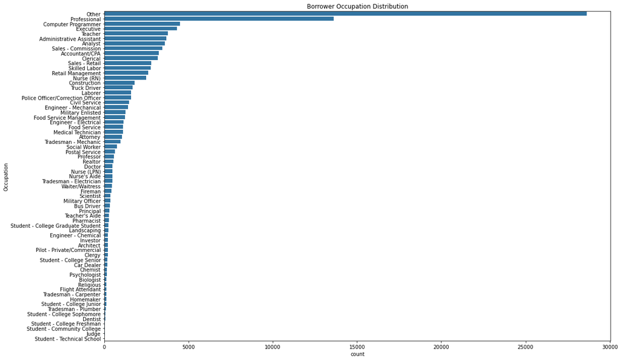

```python
cat_hbarplot(prosper_clean, 'Occupation', 'Borrower Occupation Distribution', labels=False ,graph_height=12)
```

Many borrowers can't identify themselves with an occupation suggested by Prosper or maybe they don't want to reveal that piece of information as indicated by Other. However, Compouter Programmers and Analysts are among the top 10 clients while Students don't borrow that much!

### Verifiable Income and Home Ownership

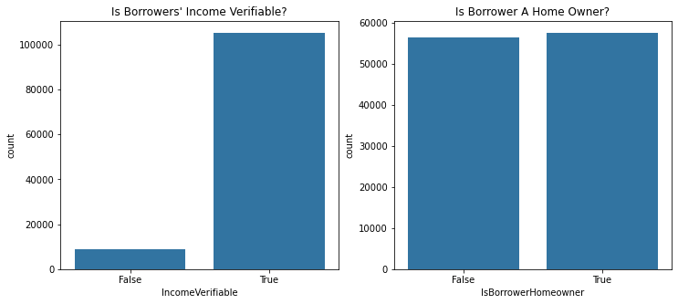

```python
plt.figure(figsize=[12, 5])
base_color = sb.color_palette()[0]
plt.subplot(1, 2, 1)
sb.countplot(data=prosper_clean,
             x='IncomeVerifiable',
             color=base_color);
plt.title("Is Borrowers' Income Verifiable?");
plt.subplot(1, 2, 2)
sb.countplot(data=prosper_clean,
             x='IsBorrowerHomeowner',
             color=base_color);
plt.title('Is Borrower A Home Owner?');
```

Unlike home ownership, it's clear that having a verifiable source of income greatly boosts the ability of a person to borrow a loan.

## 2. Loan Data

### Loan Original Amount

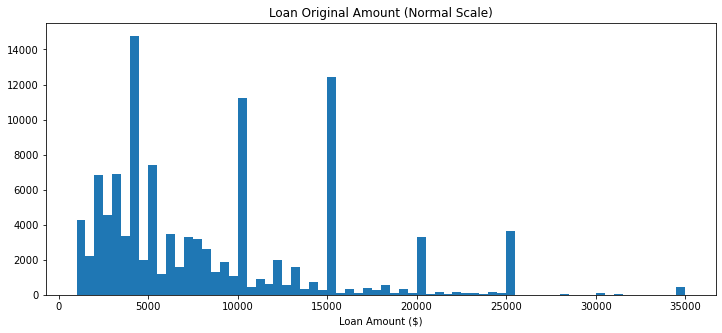

```python
# Loan Amount distribution
plt.figure(figsize=[12, 5]);
binsize = 500
bins = np.arange(prosper_clean['LoanOriginalAmount'].min(), prosper_clean['LoanOriginalAmount'].max()+binsize, binsize)
plt.hist(data=prosper_clean,
         x='LoanOriginalAmount',
         bins=bins)
plt.xlabel('Loan Amount ($)')
plt.title('Loan Original Amount (Normal Scale)');
```

The distribution is right skewed with peaks at 4K, 10K, 15K, 20K, and 25K. Let's try this on a log scale and see what we get.

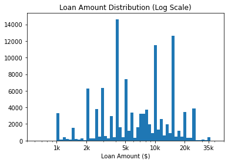

```python
#  transforming the bins to the log scale
log_binsize = 0.03
bins = 10 ** np.arange(log_trans(prosper_clean['LoanOriginalAmount'].min()), log_trans(prosper_clean['StatedMonthlyIncome'].max())+log_binsize, log_binsize)

plt.hist(data=prosper_clean,
         x = 'LoanOriginalAmount',
         bins = bins)
plt.xscale('log')

#  limiting the data to values between 500 and 50K where most of the data fall between
plt.xlim(5e2, 5e4)

#  using proper tick values and their right locations
plt.xticks([1e3, 2e3, 5e3, 1e4, 2e4, 3.5e4],
           ['1k', '2k','5k', '10k', '20k', '35k'])
plt.xlabel('Loan Amount ($)')
plt.title('Loan Amount Distribution (Log Scale)')
plt.show();
```

I don't know if I'm allowed to say this, but if we ignore the peaks at 10K and 15K for a second, we end up with a log-normal distribution of Loan Amount with a central peak at nearly 4K $.

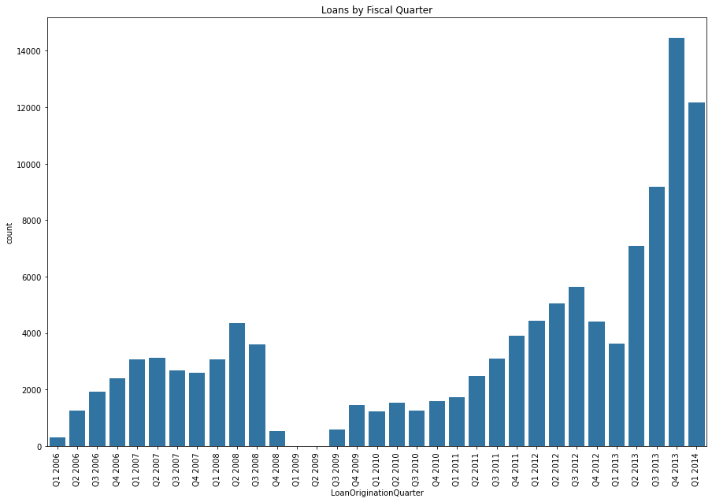

```python
#  displaying the result with the chosen title
plt.figure(figsize=[15, 10])
sb.countplot(data=prosper_clean,
             x='LoanOriginationQuarter',
             color=base_color);
plt.xticks(rotation=90);
plt.title('Loans by Fiscal Quarter');
```

It looks like Prosper had a rough start during the first 3 years, followed by a shutdown in the first quarter of 2009 then the number of loans started to increase steadily for the next 4 years. Finally the number of loans hit the roof all of a sudden starting from the second quarter of 2013.

### Loan Terms

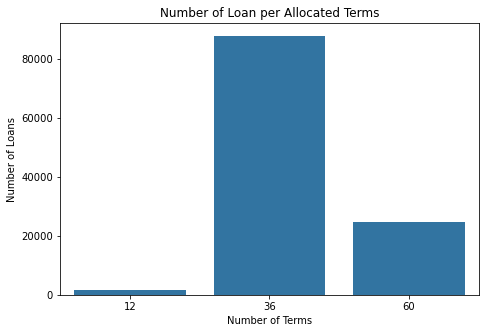

```python
#  displaying the result with the chosen title
plt.figure(figsize=[7.5, 5])
sb.countplot(data=prosper_clean,
             x='Term',
             color=base_color);
plt.xlabel('Number of Terms');
plt.ylabel('Number of Loans')
plt.title('Number of Loan per Allocated Terms');
```

Most of the borrowers prefer the 3-year long term over the others.

### Listing Category

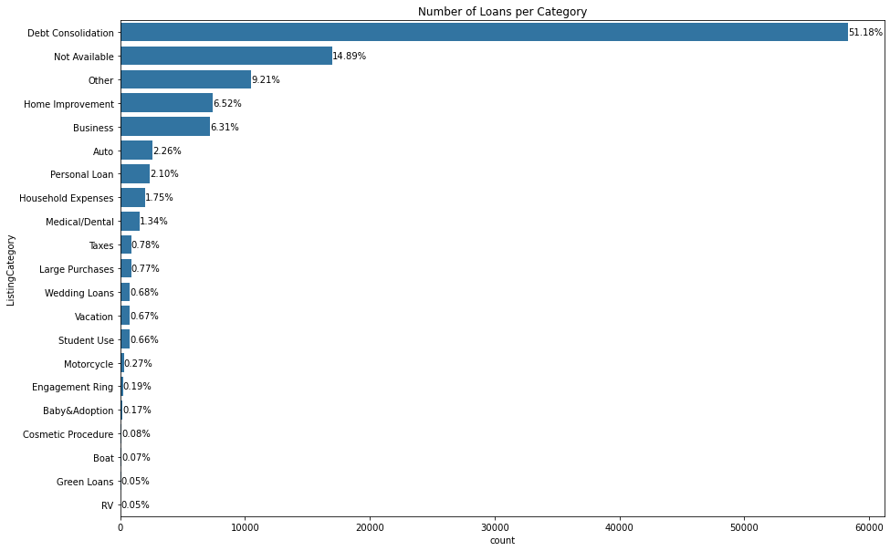

```python
cat_hbarplot(prosper_clean, 'ListingCategory', 'Number of Loans per Category')
```

- Over half of debts is directed toward paying other debts!
- about 25% is either not available or not covered by categories offered by Prosper.
- the remaining 25% is mainly dominated by Home Improvement or Business purposes.

### Borrower Rate

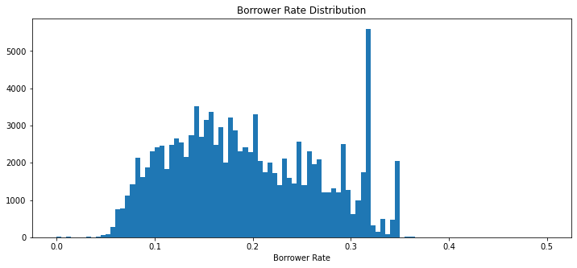

```python
# Borrower APR distribution
plt.figure(figsize=[12, 5]);
binsize = 0.005
bins = np.arange(prosper_clean['BorrowerRate'].min(), prosper_clean['BorrowerRate'].max()+binsize, binsize)
plt.hist(data=prosper_clean,
         x='BorrowerRate',
         bins=bins)
plt.xlabel('Borrower Rate')
plt.title('Borrower Rate Distribution');
```

The distribution is mostly normal around 0.18 except for a spike at 0.32. We need to check the reason for this spike and at what quarter it happened.

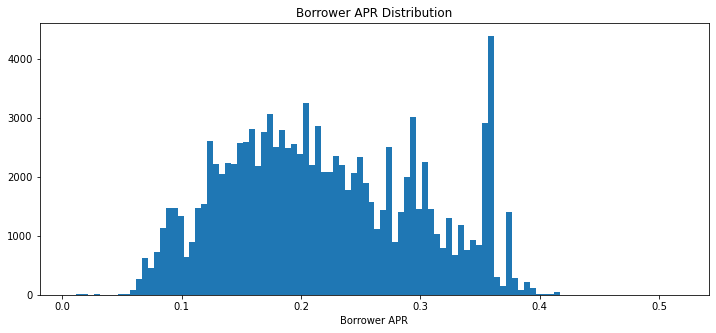

```python
# Borrower APR distribution
plt.figure(figsize=[12, 5]);
binsize = 0.005
bins = np.arange(prosper_clean['BorrowerAPR'].min(), prosper_clean['BorrowerAPR'].max()+binsize, binsize)
plt.hist(data=prosper_clean,
         x='BorrowerAPR',
         bins=bins)
plt.xlabel('Borrower APR')
plt.title('Borrower APR Distribution');
```

As expected it show the same distribution previously displayed by Borrower Rate.

### Loan Status

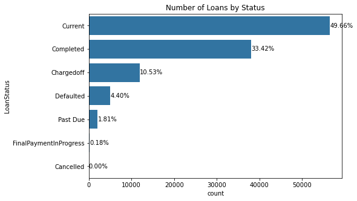

```python
cat_hbarplot(prosper_clean, 'LoanStatus', 'Number of Loans by Status', graph_height=5)
```

- 50% of loans are up in the air, and we don't know if they would be completed or defaulted.
- Judging by these numbers, current loans have nearly twice the chance to be completed rather than (defaulted, chargedoff, or getting Past Due)

After a little playing around with the available variables about both Borrowers and their Loans, let's dive deeper and seek an answer for our main question: What varaibles affect Borrower Rate?

## Credit Risk Metrics

Before Q3 2009, Credit Grade was the metric displayed for investors to show how healthy the borrower's credit is. So, I'll start with it and see how it's distributed.

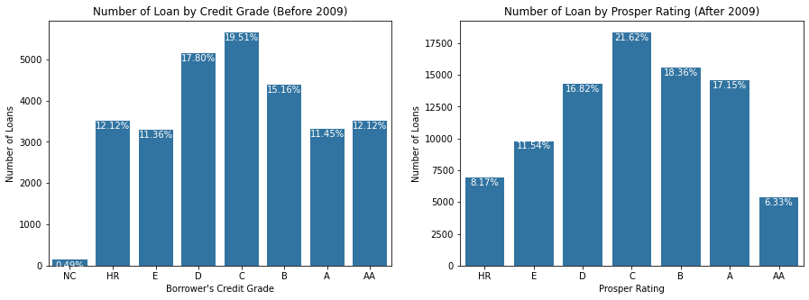

```python
def disp_prctg(df, var, top_padding=500):
    """
    Display percentage of each category annotated to the corresponding bar

    Parameters
    ----------
    df: variable name referencing to the dataframe
    var: string value of the column name
    """
    n_points = df.shape[0] - pd.isna(df[str(var)]).sum()
    cat_counts = df[str(var)].value_counts()
        # loop through each pair of locations and labels
    for loc, label in zip(locs, labels):

        # get the text property for the label to get the correct count
        count = cat_counts[label.get_text()]
        pct_string = '{:0.2f}%'.format(100*count/n_points)

        # print the annotation just below the top of the bar
        plt.text(loc, count-top_padding, pct_string, ha = 'center', color = 'w')


plt.figure(figsize=[15, 5])

#  Credit Grade plot
plt.subplot(1, 2, 1)
sb.countplot(data=prosper_clean,
             x='CreditGrade',
             color=base_color);
plt.xlabel("Borrower's Credit Grade");
plt.ylabel('Number of Loans')
plt.title('Number of Loan by Credit Grade (Before 2009)');

locs, labels = plt.xticks() # get the current tick locations and labels
disp_prctg(prosper_clean, 'CreditGrade', top_padding=200)

#  Prosper Rating plot
plt.subplot(1, 2, 2)
sb.countplot(data=prosper_clean,
             x='ProsperRating',
             color=base_color);
plt.xlabel("Prosper Rating");
plt.ylabel('Number of Loans')
plt.title('Number of Loan by Prosper Rating (After 2009)');
locs, labels = plt.xticks() # get the current tick locations and labels
disp_prctg(prosper_clean, 'ProsperRating', top_padding=600)
```

As mentioned previously, Credit Grade is based on buckets,designed by Prosper, to pigeonhole borrower's credit score of an independent credit reporting agency. While Prosper Rating is based on the company's Prosper Score as well as borrower credit information. I'll start the investigation by creating a plot matrix between borrower credit numeric variables and borrower history with Prosper.

### Prosper Score

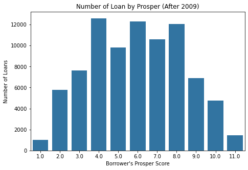

```python
plt.figure(figsize=[7.5, 5])

#  Prosper Score distribution
sb.countplot(data=prosper_clean,
             x='ProsperScore',
             color=base_color);
plt.xlabel("Borrower's Prosper Score");
plt.ylabel('Number of Loans')
plt.title('Number of Loan by Prosper (After 2009)');
```

There are three peaks at Prosper Scores of 4, 6, and 8 and the distribution is fairly normal.

### Borrower Credit Information

#### Credit Score (provided by consumer credit rating agency)

I'll create a new column, CreditScoreAVG, equal to the mean of CreditScoreRangeLower and CreditScoreRangeUpper to see how it's distributed.

```python
#  just to keep in mind the difference between the number of records in each case
print('{} loans were originated pre-09\nwhile {} loans were originated post-09\npost-09 records are almost {} times pre-09 records'.format(prosper_01.shape[0], prosper_02.shape[0], np.ceil(prosper_02.shape[0]/prosper_01.shape[0])))
```

```
28931 loans were originated pre-09
while 84853 loans were originated post-09
post-09 records are almost 3.0 times pre-09 records
```

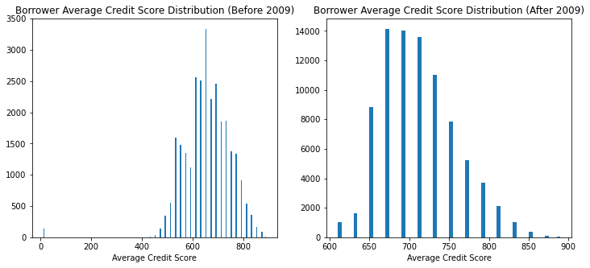

```python
# Average Credit Score distribution
plt.figure(figsize=[12, 5]);

#  before 2009
plt.subplot(1, 2, 1);
binsize = 5
bins = np.arange(prosper_01['CreditScoreAVG'].min(), prosper_01['CreditScoreAVG'].max()+binsize, binsize)
plt.hist(data=prosper_01,
         x='CreditScoreAVG',
         bins=bins)
plt.xlabel('Average Credit Score')
plt.title('Borrower Average Credit Score Distribution (Before 2009)');

#  after 2009
plt.subplot(1, 2, 2);
binsize = 5
bins = np.arange(prosper_02['CreditScoreAVG'].min(), prosper_02['CreditScoreAVG'].max()+binsize, binsize)
plt.hist(data=prosper_02,
         x='CreditScoreAVG',
         bins=bins)
plt.xlabel('Average Credit Score')
plt.title('Borrower Average Credit Score Distribution (After 2009)');
```

#### Inquires Last 6 Months

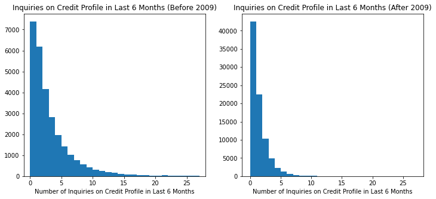

```python
# Inquires Last 6 Months distribution
plt.figure(figsize=[12, 5]);

#  before 2009
plt.subplot(1, 2, 1);
binsize = 1
bins = np.arange(prosper_01['InquiriesLast6Months'].min(), prosper_01['InquiriesLast6Months'].max()+binsize, binsize)
plt.hist(data=prosper_01,
         x='InquiriesLast6Months',
         bins=bins)
plt.xlabel('Number of Inquiries on Credit Profile in Last 6 Months')
plt.title('Inquiries on Credit Profile in Last 6 Months (Before 2009)');
plt.xlim(-1, 28); #  removing outliers

#  after 2009
plt.subplot(1, 2, 2);
binsize = 1
bins = np.arange(prosper_02['InquiriesLast6Months'].min(), prosper_02['InquiriesLast6Months'].max()+binsize, binsize)
plt.hist(data=prosper_02,
         x='InquiriesLast6Months',
         bins=bins)
plt.xlabel('Number of Inquiries on Credit Profile in Last 6 Months')
plt.title('Inquiries on Credit Profile in Last 6 Months (After 2009)');
```

- When I removed outliers from the pre-09 plot (44 records having more than 30 inquiries), the shapes of distribution became nearly identical with the post-09 plot. However, there appears to be a bias toward borrowers with a small number of inquiries (Indicated by the differenc in counts of first five consecutive bins)
- It looks like an upper limit was posed on the number of inquiries allowable per credit profile in the company's second iteration (27)

#### Delinquencies Last 7 Years

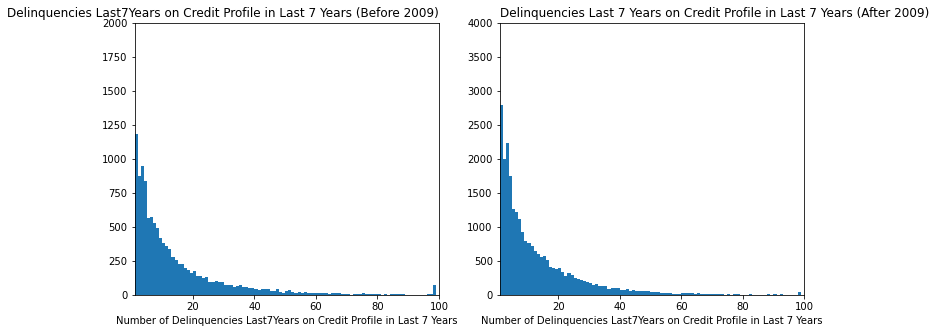

```python
# Delinquencies Last 7 Yeaers distribution
plt.figure(figsize=[12, 5]);

#  before 2009
plt.subplot(1, 2, 1);
binsize = 1
bins = np.arange(prosper_01['DelinquenciesLast7Years'].min(), prosper_01['DelinquenciesLast7Years'].max()+binsize, binsize)
plt.hist(data=prosper_01,
         x='DelinquenciesLast7Years',
         bins=bins)
plt.xlabel('Number of Delinquencies Last7Years on Credit Profile in Last 7 Years')
plt.title('Delinquencies Last7Years on Credit Profile in Last 7 Years (Before 2009)', loc='right');
plt.xlim(1, 100);
plt.ylim(0, 2000);

#  after 2009
plt.subplot(1, 2, 2);
binsize = 1
bins = np.arange(prosper_02['DelinquenciesLast7Years'].min(), prosper_02['DelinquenciesLast7Years'].max()+binsize, binsize)
plt.hist(data=prosper_02,
         x='DelinquenciesLast7Years',
         bins=bins)
plt.xlabel('Number of Delinquencies Last7Years on Credit Profile in Last 7 Years')
plt.title('Delinquencies Last 7 Years on Credit Profile in Last 7 Years (After 2009)', loc='left');
plt.xlim(1, 100);
plt.ylim(0, 4000);
```

Distributions in both cases are nearly identical and are right skewed with mode of 0

#### Public Record Last 12 Months

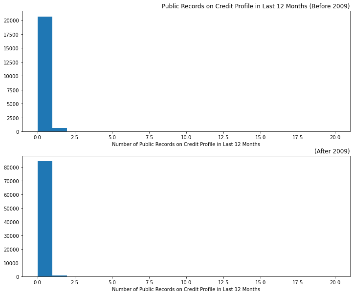

```python
# Public Record Last 12 Months distribution
plt.figure(figsize=[12, 10]);

#  before 2009
ax1 = plt.subplot(2, 1, 1);
binsize = 1
bins = np.arange(prosper_01['PublicRecordsLast12Months'].min(), prosper_01['PublicRecordsLast12Months'].max()+binsize, binsize)
plt.hist(data=prosper_01,
         x='PublicRecordsLast12Months',
         bins=bins)
plt.xlabel('Number of Public Records on Credit Profile in Last 12 Months')
plt.title('Public Records on Credit Profile in Last 12 Months (Before 2009)', loc='right');

#  after 2009
plt.subplot(2, 1, 2, sharex=ax1);
binsize = 1
bins = np.arange(prosper_02['PublicRecordsLast12Months'].min(), prosper_02['PublicRecordsLast12Months'].max()+binsize, binsize)
plt.hist(data=prosper_02,
         x='PublicRecordsLast12Months',
         bins=bins)
plt.xlabel('Number of Public Records on Credit Profile in Last 12 Months')
plt.title('(After 2009)', loc='right');
```

The distribution looks nearly identical except for some outliers in the post-09 data. Let's see who they are!

```python
prosper_02[prosper_02['PublicRecordsLast12Months'] > prosper_01['PublicRecordsLast12Months'].max()]
```

|  | LoanOriginationDate | LoanOriginationQuarter | LoanOriginalAmount | Term | LoanStatus | BorrowerRate | BorrowerAPR | ProsperRating | ProsperRating (numeric) | ProsperScore | CreditGrade | CreditScoreRangeLower | CreditScoreRangeUpper | InquiriesLast6Months | DelinquenciesLast7Years | PublicRecordsLast12Months | RevolvingCreditBalance | BankcardUtilization | AvailableBankcardCredit | TradesOpenedLast6Months | DebtToIncomeRatio | BorrowerState | Occupation | EmploymentStatus | EmploymentStatusDuration | IsBorrowerHomeowner | IncomeRange | IncomeVerifiable | StatedMonthlyIncome | … |
| --- | --- | --- | --- | --- | --- | --- | --- | --- | --- | --- | --- | --- | --- | --- | --- | --- | --- | --- | --- | --- | --- | --- | --- | --- | --- | --- | --- | --- | --- | --- |
| 48338 | 2013-06-24 | Q2 2013 | 9500 | 60 | Current | 0.1984 | 0.22283 | C | 4.0 | 5.0 | NaN | 660.0 | 679.0 | 0.0 | 0.0 | 20.0 | 139053.0 | 0.85 | 23806.0 | 0.0 | NaN | OH | Executive | Self-employed | 201.0 | False | $100,000+ | False | 8333.333333 | … |

#### Revolving Credit Balance

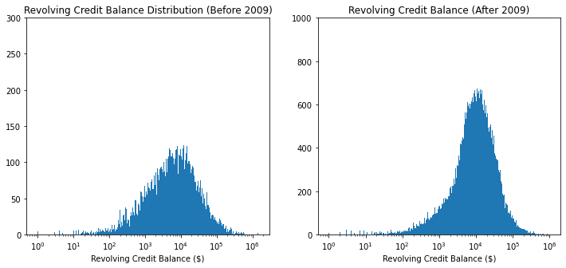

```python
# Revolving Credit Balance distribution
plt.figure(figsize=[12, 5]);

#  before 2009
plt.subplot(1, 2, 1);
log_binsize = 0.01
bins = 10 ** np.arange(log_trans(1), log_trans(prosper_01['RevolvingCreditBalance'].max())+log_binsize, log_binsize)
plt.hist(data=prosper_01,
         x='RevolvingCreditBalance',
         bins=bins)
plt.xlabel('Revolving Credit Balance ($)')
plt.title('Revolving Credit Balance Distribution (Before 2009)');
plt.xscale('log');
plt.ylim(0, 300);

#  after 2009
plt.subplot(1, 2, 2);
log_binsize = 0.01
bins = 10 ** np.arange(log_trans(1), log_trans(prosper_02['RevolvingCreditBalance'].max())+log_binsize, log_binsize)
plt.hist(data=prosper_02,
         x='RevolvingCreditBalance',
         bins=bins)
plt.xscale('log');
plt.xlabel('Revolving Credit Balance ($)')
plt.title('Revolving Credit Balance (After 2009)');
plt.ylim(0, 1000);
```

- The mean is the same in both cases. However, the post-09 is slightly left skewed, showing bias toward borrowers with high Revoloving Credit Balance.

#### Bank Card Utilization

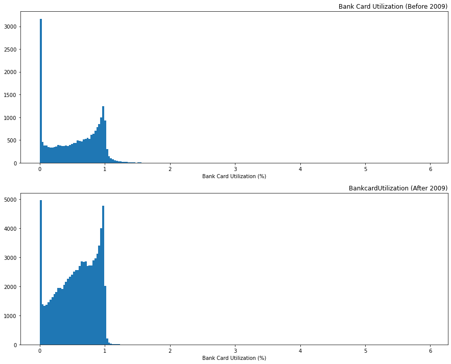

```python
# Bank Card Utilization distribution
plt.figure(figsize=[15, 12]);

#  before 2009
ax1 = plt.subplot(2, 1, 1);
binsize = 0.03
bins = np.arange(prosper_01['BankcardUtilization'].min(), prosper_01['BankcardUtilization'].max()+binsize, binsize)
plt.hist(data=prosper_01,
         x='BankcardUtilization',
         bins=bins)
plt.xlabel('Bank Card Utilization (%)')
plt.title('Bank Card Utilization (Before 2009)', loc='right');

#  after 2009
plt.subplot(2, 1, 2, sharex=ax1);
binsize = 0.03
bins = np.arange(prosper_02['BankcardUtilization'].min(), prosper_02['BankcardUtilization'].max()+binsize, binsize)
plt.hist(data=prosper_02,
         x='BankcardUtilization',
         bins=bins)
plt.xlabel('Bank Card Utilization (%)')
plt.title('BankcardUtilization (After 2009)', loc='right');
```

- Bank Card Utilization according to the available defenition: the percentage of available revolving credit that it is utilized at the time the credit profile was pulled.
- This value should be a minimum. And it seems they decided a cut-off value around 1%, above which the listing is subject to other variables deciding whether it would be accepted or not and surely will increase the Borrower Rate. We'll look further into it later.

#### Available Bank Card Credit

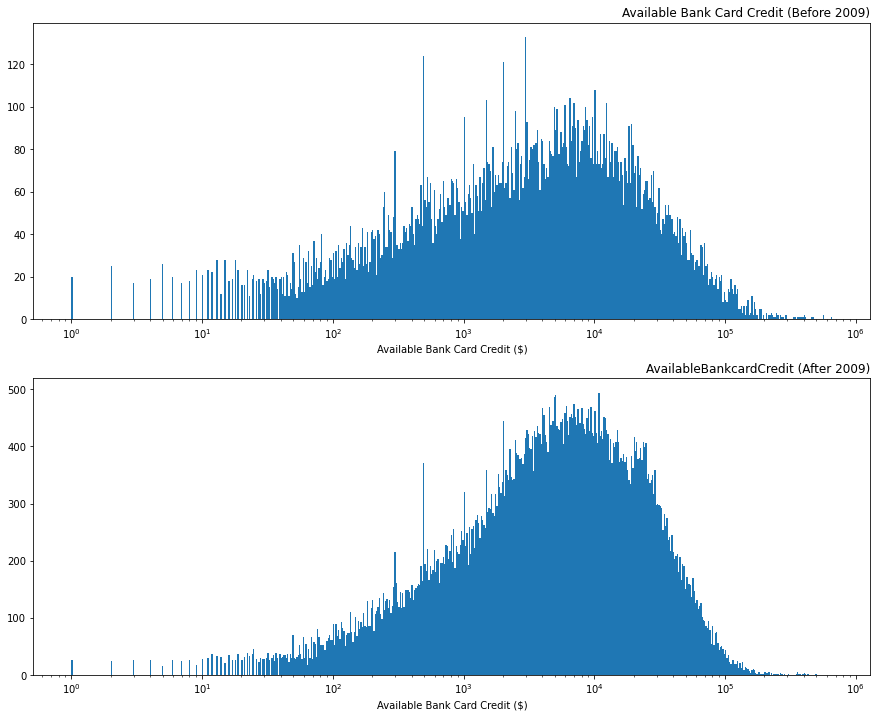

```python
# Available Bank Card Credit distribution
plt.figure(figsize=[15, 12]);

#  before 2009
ax1 = plt.subplot(2, 1, 1);
binsize = 0.01
#  excluding zero as we can't calculate the log10 of 0
bins = 10 ** np.arange(log_trans(1), log_trans(prosper_01['AvailableBankcardCredit'].max())+binsize, binsize)
plt.hist(data=prosper_01,
         x='AvailableBankcardCredit',
         bins=bins)
plt.xscale('log');
plt.xlabel('Available Bank Card Credit ($)')
plt.title('Available Bank Card Credit (Before 2009)', loc='right');

#  after 2009
ax2 = plt.subplot(2, 1, 2, sharex=ax1);
binsize = 0.01
bins = 10 ** np.arange(log_trans(1), log_trans(prosper_02['AvailableBankcardCredit'].max())+binsize, binsize)
plt.hist(data=prosper_02,
         x='AvailableBankcardCredit',
         bins=bins)
plt.xscale('log');
plt.xlabel('Available Bank Card Credit ($)')
plt.title('AvailableBankcardCredit (After 2009)', loc='right');
```

- Both distributions are left-skewed on log-scale, with almost the same peak.

#### Trades Opened Last 6 Months

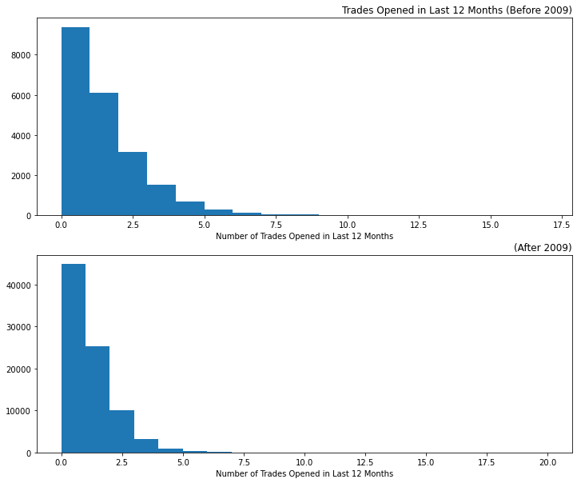

```python
# Public Record Last 12 Months distribution
plt.figure(figsize=[12, 10]);

#  before 2009
plt.subplot(2, 1, 1);
binsize = 1
bins = np.arange(prosper_01['TradesOpenedLast6Months'].min(), prosper_01['TradesOpenedLast6Months'].max()+binsize, binsize)
plt.hist(data=prosper_01,
         x='TradesOpenedLast6Months',
         bins=bins)
plt.xlabel('Number of Trades Opened in Last 12 Months')
plt.title('Trades Opened in Last 12 Months (Before 2009)', loc='right');

#  after 2009
plt.subplot(2, 1, 2);
binsize = 1
bins = np.arange(prosper_02['TradesOpenedLast6Months'].min(), prosper_02['TradesOpenedLast6Months'].max()+binsize, binsize)
plt.hist(data=prosper_02,
         x='TradesOpenedLast6Months',
         bins=bins)
plt.xlabel('Number of Trades Opened in Last 12 Months')
plt.title('(After 2009)', loc='right');
```

#### Debt To Income Ratio

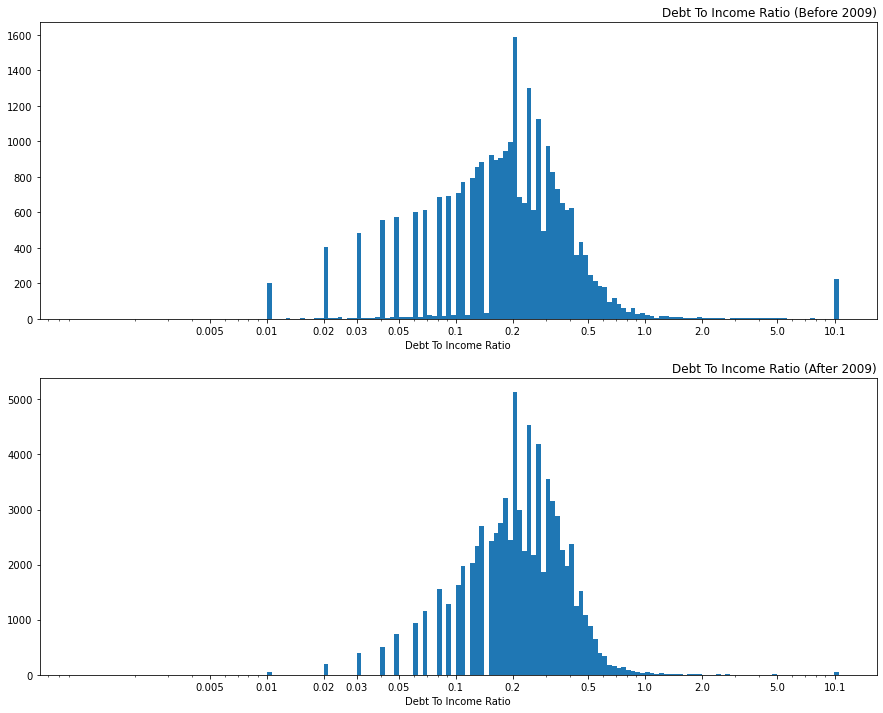

```python
# Debt To Income Ratio distribution
plt.figure(figsize=[15, 12]);

#  before 2009
ax1 = plt.subplot(2, 1, 1);
binsize = 0.025
bins = 10 ** np.arange(-3, log_trans(prosper_01['DebtToIncomeRatio'].max())+binsize, binsize)
plt.hist(data=prosper_01,
         x='DebtToIncomeRatio',
         bins=bins)
plt.xscale('log');
ax1.set_xticks(ticks=[0.005, 0.01, 0.02, 0.03, 0.05, 0.1, 0.2, 0.5, 1.0, 2.0, 5.0, 10.1])
ax1.set_xticklabels(labels=['0.005', '0.01', '0.02', '0.03', '0.05', '0.1', '0.2', '0.5', '1.0', '2.0', '5.0', '10.1'])
plt.xlabel('Debt To Income Ratio');
plt.title('Debt To Income Ratio (Before 2009)', loc='right');

#  after 2009
ax2 = plt.subplot(2, 1, 2);
binsize = 0.025
bins = 10 ** np.arange(-3, log_trans(prosper_02['DebtToIncomeRatio'].max())+binsize, binsize)
plt.hist(data=prosper_02,
         x='DebtToIncomeRatio',
         bins=bins)
plt.xscale('log');
ax2.set_xticks(ticks=[0.005, 0.01, 0.02, 0.03, 0.05, 0.1, 0.2, 0.5, 1, 2.0, 5.0, 10.1])
ax2.set_xticklabels(labels=['0.005', '0.01', '0.02', '0.03', '0.05', '0.1', '0.2', '0.5', '1.0', '2.0', '5.0', '10.1'])
plt.xlabel('Debt To Income Ratio')
plt.title('Debt To Income Ratio (After 2009)', loc='right');
```

### Risk Metrics Related to Borrowers with History Dealing with Prosper

#### Total Prosper Loans

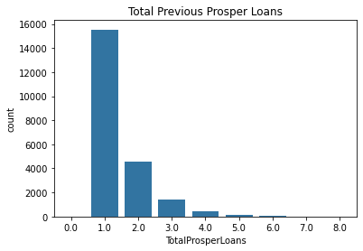

```python
#  displaying the result with the chosen title
sb.countplot(data=prosper_clean,
             x='TotalProsperLoans',
             color=base_color);
plt.title('Total Previous Prosper Loans');
```

Most of the borrowers have only dealt one time with Prosper before they applied for their second loan.

#### Prosper Principal Outstanding

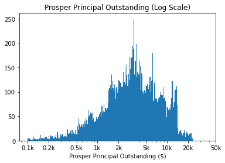

```python
#  transforming the bins to the log scale
log_binsize = 0.01
#  setting the minimum value to 2 as there are over 1000 records with Principal Outstanding <= 1
bins = 10 ** np.arange(2, log_trans(prosper_clean['ProsperPrincipalOutstanding'].max())+log_binsize, log_binsize)

plt.hist(data=prosper_clean,
         x = 'ProsperPrincipalOutstanding',
         bins = bins)
plt.xscale('log')

#  using proper tick values and their right locations
plt.xticks([1e2, 2e2, 5e2, 1e3, 2e3, 5e3, 1e4, 2e4, 5e4],
           ['0.1k', '0.2k','0.5k', '1k', '2k', '5k', '10k', '20k', '50k'])
plt.xlabel('Prosper Principal Outstanding ($)')
plt.title('Prosper Principal Outstanding (Log Scale)')
plt.show();
```

- On a log-scale the Principal Outstanding is slightly left skewed, showing bias toward borrowers with somehow high values, but not so much that it would damage their ability to pay their debts.
- The peak value is around 3K, but borrower with higher Principal Outstanding values count for a large portion of the distribution.

#### ScorexChangeAtTimeOfListing

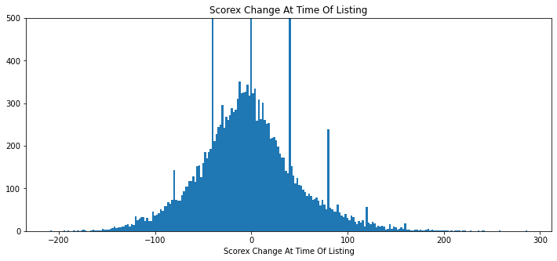

```python
# ScorexChangeAtTimeOfListing
plt.figure(figsize=[12, 5]);
binsize = 2
bins = np.arange(prosper_clean['ScorexChangeAtTimeOfListing'].min(), prosper_clean['ScorexChangeAtTimeOfListing'].max()+binsize, binsize)
plt.hist(data=prosper_clean,
         x='ScorexChangeAtTimeOfListing',
         bins=bins)
plt.xlabel('Scorex Change At Time Of Listing')
plt.ylim(0, 500)
plt.title('Scorex Change At Time Of Listing');
```

- The distribution is fairly normal, with a peak value around 0

#### Payments Delay

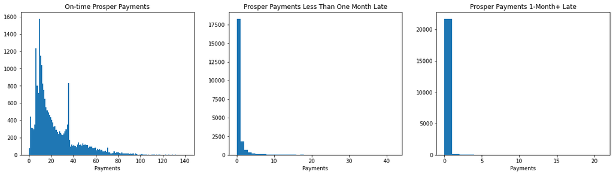

```python
plt.figure(figsize=[20, 5])

#  Payments on time
plt.subplot(1, 3, 1);
binsize = 1
bins = np.arange(prosper_clean['OnTimeProsperPayments'].min(), prosper_clean['OnTimeProsperPayments'].max()+binsize, binsize)
plt.hist(data=prosper_clean,
         x='OnTimeProsperPayments',
         bins=bins)
plt.xlabel('Payments')
plt.title('On-time Prosper Payments');

#  less than one-month late
plt.subplot(1, 3, 2);
binsize = 1
bins = np.arange(prosper_clean['ProsperPaymentsLessThanOneMonthLate'].min(), prosper_clean['ProsperPaymentsLessThanOneMonthLate'].max()+binsize, binsize)
plt.hist(data=prosper_clean,
         x='ProsperPaymentsLessThanOneMonthLate',
         bins=bins)
plt.xlabel('Payments')
plt.title('Prosper Payments Less Than One Month Late');

#  over one-month late
plt.subplot(1, 3, 3);
binsize = 1
bins = np.arange(prosper_clean['ProsperPaymentsOneMonthPlusLate'].min(), prosper_clean['ProsperPaymentsOneMonthPlusLate'].max()+binsize, binsize)
plt.hist(data=prosper_clean,
         x='ProsperPaymentsOneMonthPlusLate',
         bins=bins)
plt.xlabel('Payments')
plt.title('Prosper Payments 1-Month+ Late');
```

Borrowers tend to pay their debts on time. I'll check later if payments dealy would affect the borrower rate

### Discuss the distribution(s) of your variable(s) of interest. Were there any unusual points? Did you need to perform any transformations?

Most of the variables are normally distributed. Others were skewed, but showed normal distribution on log-scale such as monthly income, revolving credit, available bank credit, debt-to-income ratio, and prosper outstanding principal

### Of the features you investigated, were there any unusual distributions? Did you perform any operations on the data to tidy, adjust, or change the form of the data? If so, why did you do this?

- Borrowers are mostly low-to-mid class citizens with income ranges from 25k to 75k.
- Loans are mostly geared toward consolidating other debts.
- Unlike home ownership, having a verifiable source of income helps borrowers land a loan.
- loans have a bette chance ending up completed rather than defaulted or charged-off.
- Bank Card Utilization should be a minimum. And it seems they decided a cut-off value around 1%, above which the listing is subject to other variables deciding whether it would be accepted or not and surely will increase the Borrower Rate.
- When comparing Credit Grade and Prosper Rating, the new metric for credit rating lowered the percentage of HR loans and AA's as well. It also prohibited giving loans to borrowers with no credit (NC)

## Bivariate Plots

To guide our way through next section, I'll start with plotting a correlation matrix among numeric variables of interest.

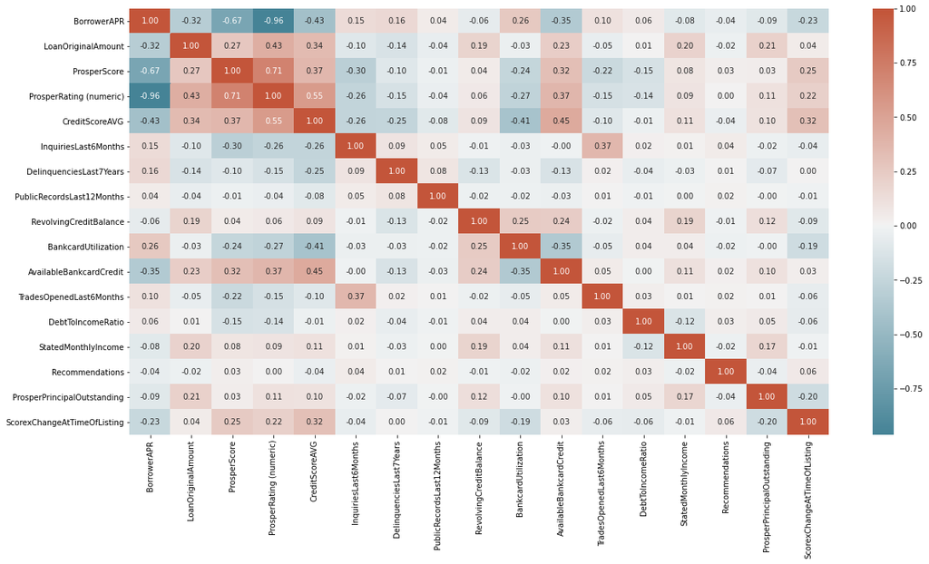

```python
prosper_num = ['BorrowerAPR', 'LoanOriginalAmount', 'ProsperScore', 'ProsperRating (numeric)', 'CreditScoreAVG', 'InquiriesLast6Months',
              'DelinquenciesLast7Years', 'PublicRecordsLast12Months', 'RevolvingCreditBalance', 'BankcardUtilization', 'AvailableBankcardCredit',
              'TradesOpenedLast6Months', 'DebtToIncomeRatio', 'StatedMonthlyIncome', 'Recommendations', 'ProsperPrincipalOutstanding',
              'ScorexChangeAtTimeOfListing']
cmap = sb.diverging_palette(220, 20, as_cmap=True)
plt.figure(figsize=[20, 10])
sb.heatmap(raw[prosper_num].corr(),
            cmap=cmap,
            annot=True,
            fmt='.2f',
            center=0);
```